# Fastball Study

## Model Fit

```r
stan_beta_fastball <- '
data {
  int<lower=1> n;     // number of observations
  vector<lower=0,upper=1>[n] whiff_rate;    // response
  vector[n] velo;     // predictor
  vector[n] spin_rate;     // predictor
  vector[n] extension;     // predictor
  vector[n] arm_angle;     // predictor
  vector[n] ivb;     // predictor
}
parameters {
  real<lower=0> kappa2;  // concentration of beta dist
  real b0;               // intercept
  real b1;              // slope for velo
  real b2;              // slope for spin_rate
  real b3;              // slope for extension
  real b4;              // slope for interaction between arm_angle and ivb
  real b5;              // slope for arm_angle
  real b6;              // slope for ivb

}
model {
  vector[n] omega;
  vector[n] alpha;
  vector[n] beta;
  for ( i in 1:n ) {
    omega[i] = inv_logit(b0 + b1 * velo[i] + b2 * spin_rate[i]+ b3 * extension[i]+ b4 * (arm_angle[i] * ivb[i])+ b5 * arm_angle[i]+ b6 * ivb[i]);
    alpha[i] = omega[i] * (kappa2) + 1;
    beta[i] = (1 - omega[i]) * (kappa2) + 1;
  }

  b0 ~ normal(-1.283235, 1);
  b1 ~ cauchy(0, 2.5);
  b2 ~ cauchy(0, 2.5);
  b3 ~ cauchy(0, 2.5);
  b4 ~ cauchy(0, 2.5);
  b5 ~ cauchy(0, 2.5);
  b6 ~ cauchy(0, 2.5);
  kappa2 ~ lognormal(0,2);
  whiff_rate ~ beta(alpha, beta); // have to use alpha, beta parameterization for beta()
}


generated quantities {
 // this is not really required - only if you want values of omega, alpha, beta included in your fitted model
  vector[n] omega;
  vector[n] alpha;
  vector[n] beta;
  for (i in 1:n) {
    omega[i] = inv_logit(b0 + b1 * velo[i] + b2 * spin_rate[i]+ b3 * extension[i]+ b4 * (arm_angle[i] * ivb[i])+ b5 * arm_angle[i]+ b6 * ivb[i]); // if you want stan to compute modes for each data row       dis line
    alpha[i] = omega[i] * (kappa2) + 1; // if you want the beta parameters alpha and beta for each row
    beta[i] = (1 - omega[i]) * (kappa2) + 1;
  }
  vector[n] log_lik;
  for (i in 1:n) {
    log_lik[i] = beta_lpdf(whiff_rate[i] | alpha[i], beta[i]);
  }
}'
```

```r
#compose the data
composed_fastball <- compose_data(fastball_data)
```

```r
refit_model <- FALSE
model_file <- "fastball_model_fit.RDS"
if (refit_model){
  fastball_model_fit <- rstan::stan(model_code = stan_beta_fastball,
                        data = composed_fastball,
                        chains = 4,
                        iter = 2000,
                        refresh = 0)
  saveRDS(fastball_model_fit, file = model_file)
}else{
  # if you wanted to save an RDS fitted model locally you'd do
  fastball_model_fit <- readRDS(model_file)
}
```

## Posterior

```r
fastball_model_fit
```

```
Inference for Stan model: anon_model.
4 chains, each with iter=2000; warmup=1000; thin=1;
post-warmup draws per chain=1000, total post-warmup draws=4000.

               mean se_mean   sd   2.5%    25%    50%    75%  97.5% n_eff Rhat
kappa2        13.99    0.01 0.91  12.22  13.39  13.99  14.57  15.84  3949    1
b0            -1.64    0.00 0.04  -1.72  -1.67  -1.64  -1.62  -1.58  3197    1
b1             0.18    0.00 0.03   0.11   0.15   0.18   0.20   0.24  3410    1
b2             0.12    0.00 0.04   0.04   0.09   0.12   0.14   0.19  2994    1
b3             0.07    0.00 0.03   0.00   0.04   0.07   0.09   0.13  4282    1
b4             0.00    0.00 0.02  -0.04  -0.01   0.00   0.02   0.04  3173    1
b5            -0.23    0.00 0.06  -0.34  -0.27  -0.23  -0.19  -0.13  2683    1
b6             0.10    0.00 0.05   0.00   0.06   0.10   0.13   0.21  2666    1
omega[1]       0.15    0.00 0.01   0.13   0.14   0.15   0.16   0.17  4232    1
omega[2]       0.23    0.00 0.01   0.21   0.22   0.23   0.24   0.26  3794    1
omega[3]       0.14    0.00 0.01   0.12   0.13   0.14   0.15   0.16  3625    1
omega[4]       0.21    0.00 0.01   0.19   0.20   0.21   0.22   0.24  4766    1
omega[5]       0.15    0.00 0.01   0.13   0.14   0.15   0.15   0.16  3424    1
omega[6]       0.17    0.00 0.01   0.16   0.17   0.17   0.18   0.19  2888    1
omega[7]       0.23    0.00 0.02   0.20   0.22   0.23   0.24   0.27  4505    1
omega[8]       0.22    0.00 0.01   0.20   0.21   0.22   0.22   0.24  5346    1
omega[9]       0.10    0.00 0.01   0.08   0.10   0.10   0.11   0.12  4354    1
omega[10]      0.25    0.00 0.01   0.23   0.24   0.25   0.26   0.27  5761    1
omega[11]      0.18    0.00 0.01   0.16   0.17   0.18   0.19   0.20  3982    1
omega[12]      0.17    0.00 0.01   0.16   0.17   0.17   0.18   0.19  5073    1
omega[13]      0.21    0.00 0.01   0.19   0.20   0.21   0.21   0.22  3829    1
omega[14]      0.10    0.00 0.01   0.08   0.09   0.10   0.11   0.12  3909    1
omega[15]      0.19    0.00 0.01   0.17   0.18   0.19   0.20   0.21  3687    1
omega[16]      0.21    0.00 0.01   0.19   0.20   0.21   0.22   0.23  4515    1
omega[17]      0.18    0.00 0.01   0.17   0.18   0.18   0.19   0.20  4563    1
omega[18]      0.21    0.00 0.01   0.18   0.20   0.21   0.22   0.24  3840    1
omega[19]      0.19    0.00 0.01   0.17   0.19   0.19   0.20   0.21  5566    1
omega[20]      0.14    0.00 0.01   0.12   0.13   0.14   0.14   0.15  2902    1
omega[21]      0.17    0.00 0.01   0.16   0.17   0.17   0.18   0.19  3218    1
omega[22]      0.19    0.00 0.01   0.18   0.19   0.19   0.20   0.21  3466    1
omega[23]      0.24    0.00 0.01   0.21   0.23   0.24   0.25   0.26  6433    1
omega[24]      0.19    0.00 0.01   0.17   0.18   0.19   0.19   0.21  3356    1
omega[25]      0.21    0.00 0.02   0.17   0.19   0.21   0.22   0.25  2906    1
omega[26]      0.22    0.00 0.01   0.20   0.22   0.22   0.23   0.25  3500    1
omega[27]      0.22    0.00 0.02   0.18   0.20   0.22   0.23   0.25  3972    1
```

[output cut: 2388 more lines]

```
log_lik[598]   1.38    0.00 0.03   1.32   1.36   1.38   1.40   1.43  3711    1
log_lik[599]   1.34    0.00 0.04   1.26   1.32   1.34   1.36   1.41  4016    1
log_lik[600]   1.36    0.00 0.03   1.30   1.34   1.36   1.38   1.42  3523    1
log_lik[601]   1.57    0.00 0.05   1.46   1.54   1.57   1.61   1.66  5040    1
log_lik[602]   1.19    0.00 0.05   1.08   1.16   1.19   1.23   1.28  4763    1
log_lik[603]   1.35    0.00 0.04   1.26   1.32   1.35   1.37   1.41  3293    1
log_lik[604]   1.12    0.00 0.12   0.88   1.04   1.12   1.20   1.33  2348    1
log_lik[605]   1.39    0.00 0.03   1.33   1.37   1.39   1.41   1.44  3552    1
log_lik[606]   1.38    0.00 0.04   1.30   1.35   1.38   1.40   1.44  3968    1
lp__         582.12    0.05 2.07 577.16 581.04 582.49 583.63 585.02  1718    1

Samples were drawn using NUTS(diag_e) at Fri May  2 13:33:32 2025.
For each parameter, n_eff is a crude measure of effective sample size,
and Rhat is the potential scale reduction factor on split chains (at
convergence, Rhat=1).
```

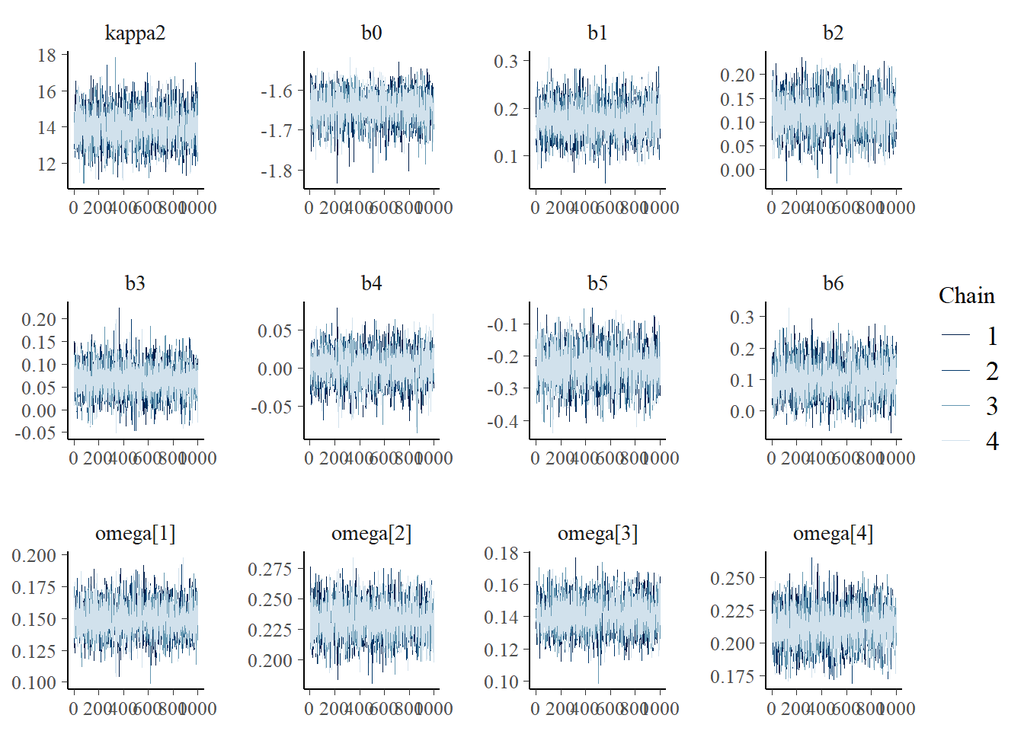

```r
draws <- as_draws_array(fastball_model_fit)

mcmc_trace(draws, pars = c("kappa2","b0", "b1","b2","b3","b4","b5","b6","omega[1]", "omega[2]","omega[3]", "omega[4]"))
```

Our trace plots all look like fuzzy caterpillars with lots of overlap. There is great mixing and no obvious patterns in any of the plots. There are also no trends positive or negative in any of them either. Since the n_eff values of all coefficients are in the thousands and all the Rhat values are 1, there’s strong evidence that the model is producing accurate results.

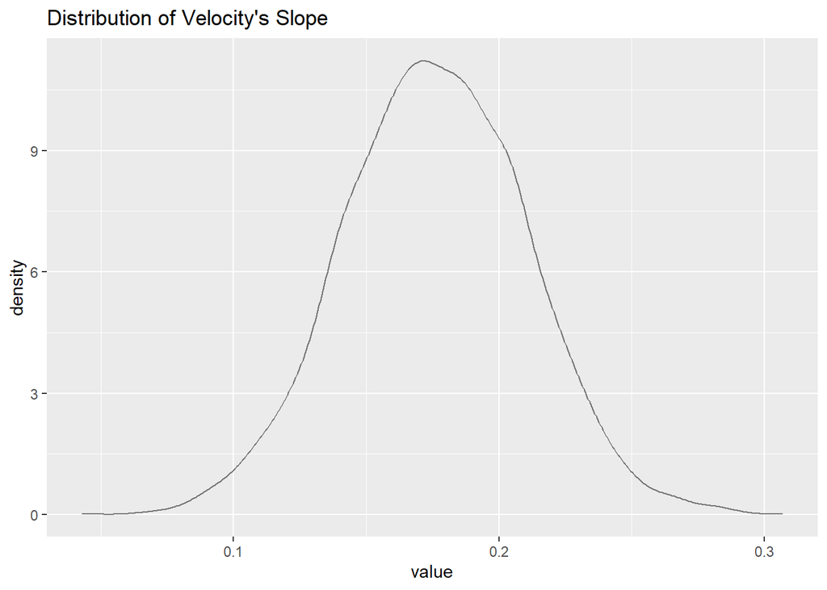

```r
psamp <- as.data.frame(fastball_model_fit) |>
  select(-lp__) |>
  pivot_longer(cols = "b1",
               names_to = 'parameter',
               values_to = 'value')
gf_dens(~value, data = psamp) |>
  gf_labs(title = "Distribution of Velocity's Slope")
```

From the model summary, we can see that b1, the coefficient for velocity, has a mean value of 0.18. The graph shows the spread of the coefficient, which ranges from about 0.05 to 0.3. Since the coefficient is positive, this means that fastball velocity and fastball whiff rate have a positive relationship, or when velocity increases, so does whiff rate.